# tidyverse

Subhalaxmi Rout

3/14/2020

## 2. Load library

```r
#install.packages("tidyverse")
#install.packages("ggplot2")
library(ggplot2)
library(tidyverse)
```

## 3. Load data to R

```r
# get the data from Git repository
url <- "https://raw.githubusercontent.com/SubhalaxmiRout002/tidyverse/master/titanic.csv"
# read the csv file
titanic_data <- read.csv(url, stringsAsFactors = FALSE)
# view fisrt 6 rows of data
head(titanic_data)
```

```
##   PassengerId Survived Pclass
## 1           1        0      3
## 2           2        1      1
## 3           3        1      3
## 4           4        1      1
## 5           5        0      3
## 6           6        0      3
##                                                  Name    Sex Age SibSp Parch
## 1                             Braund, Mr. Owen Harris   male  22     1     0
## 2 Cumings, Mrs. John Bradley (Florence Briggs Thayer) female  38     1     0
## 3                              Heikkinen, Miss. Laina female  26     0     0
## 4        Futrelle, Mrs. Jacques Heath (Lily May Peel) female  35     1     0
## 5                            Allen, Mr. William Henry   male  35     0     0
## 6                                    Moran, Mr. James   male  NA     0     0
##             Ticket    Fare Cabin Embarked
## 1        A/5 21171  7.2500              S
## 2         PC 17599 71.2833   C85        C
## 3 STON/O2. 3101282  7.9250              S
## 4           113803 53.1000  C123        S
## 5           373450  8.0500              S
## 6           330877  8.4583              Q
```

## 3. clean data

```r
# remove unwanted column
titanic_data <- titanic_data %>% select(-SibSp,-Ticket,-Fare,-Cabin,-Embarked,-Parch)

# remove where name in NA
titanic_data <- titanic_data %>% filter(!is.na(Name))

# remove duplicates from data, if present any
titanic_data <- unique(titanic_data)

# rename column
titanic_data <- titanic_data %>% rename(Class_Type = Pclass)

# view data
head(titanic_data,5)
```

```
##   PassengerId Survived Class_Type
## 1           1        0          3
## 2           2        1          1
## 3           3        1          3
## 4           4        1          1
## 5           5        0          3
##                                                  Name    Sex Age
## 1                             Braund, Mr. Owen Harris   male  22
## 2 Cumings, Mrs. John Bradley (Florence Briggs Thayer) female  38
## 3                              Heikkinen, Miss. Laina female  26
## 4        Futrelle, Mrs. Jacques Heath (Lily May Peel) female  35
## 5                            Allen, Mr. William Henry   male  35
```

## 4. Analysis

```r
# find number of survivor ratio
row <- nrow(titanic_data)

# add new colum Survived_Ration in to dataset
titanic_data <- titanic_data %>% mutate(Survived_Ratio = Survived/row)
```

## 4.1 survivor group by sex

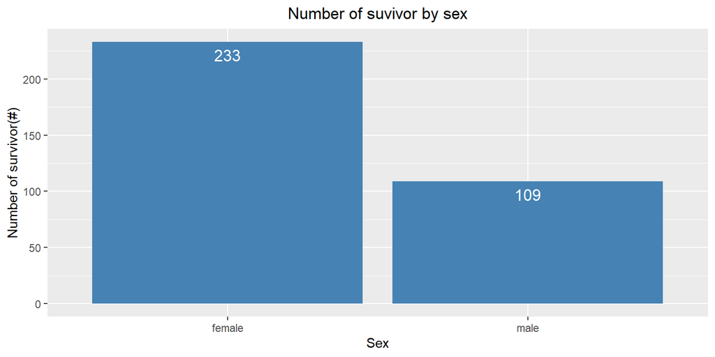

```r
# number of survivor group by sex
survivor_sex <- titanic_data %>%  filter(Survived == 1) %>% group_by(Sex) %>% count(Survived)


# draw graph
ggplot(survivor_sex) + geom_bar(aes(x = survivor_sex$Sex, y = survivor_sex$n), stat = "identity", fill = "steelblue") + xlab("Sex") + ylab("Number of survivor(#)") + ggtitle("Number of suvivor by sex") + theme(plot.title = element_text(hjust = 0.5))+ geom_text(aes(x = survivor_sex$Sex,y = survivor_sex$n,label=survivor_sex$n), vjust=1.6, color="white", size=4.5)
```

## 4.2 survivor group class type

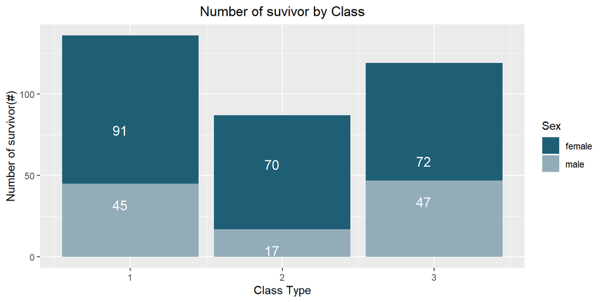

```r
# number of survivor group by class type
survivor_class <- titanic_data %>%  filter(Survived == 1) %>% group_by(Class_Type,Sex) %>% count(Survived)

# draw graph
ggplot(data = survivor_class, aes(x = survivor_class$Class_Type, y = survivor_class$n, fill = survivor_class$Sex)) + geom_bar(stat = "identity", position=position_stack())+ xlab("Class Type") + ylab("Number of survivor(#)") + ggtitle("Number of suvivor by Class") + theme(plot.title = element_text(hjust = 0.5))+ geom_text(aes(x = survivor_class$Class_Type,y = survivor_class$n,label=survivor_class$n), hjust=1.2,vjust = 2.6, color="white", size=4.5)+scale_fill_manual(values=c("#1f5f76", "#92acb8"))+labs(fill = "Sex")
```

## 5. Conclusion

From Plot 4.1 and 4.2 we found:

- The number of Surivior is high in female.
- Highest survivor is in female and Class 1 type.

I have used, select(), filter(), mutate(), rename() functions of `tidyverse` package to clean and manupulate data.

## 6. Extended–Neil Shah

I’ll take it from here Subhalaxmi Rout; great job!

The titanic data age and fair data–let’s see if there is somehow a relationship between age and survival! However upon inspecting our dataset, I saw some NA values.

This is very commong when data munging so let’s find different ways to identify them. We can use the is.na() function from manip–a tidverse package.

### is.na(X)

is.na(X) returns a boolean True or False for an input X [dataframe or vector] based on location of a NA item.

For example:

```r
head(is.na(titanic_data))
```

```
##      PassengerId Survived Class_Type  Name   Sex   Age Survived_Ratio
## [1,]       FALSE    FALSE      FALSE FALSE FALSE FALSE          FALSE
## [2,]       FALSE    FALSE      FALSE FALSE FALSE FALSE          FALSE
## [3,]       FALSE    FALSE      FALSE FALSE FALSE FALSE          FALSE
## [4,]       FALSE    FALSE      FALSE FALSE FALSE FALSE          FALSE
## [5,]       FALSE    FALSE      FALSE FALSE FALSE FALSE          FALSE
## [6,]       FALSE    FALSE      FALSE FALSE FALSE  TRUE          FALSE
```

Here we can see the NA values in the age column–but what if this was a huge dataframe and we didnd’t want to scroll through it all? Well we can use the apply() function! Apply is a very simple but super powerful function that will help with your tidying.

### apply()

Apply(X,LOC,Function) Apply will take an specifed function, and use it on the LOC [row =1 or column =2] of an input variable X.

```r
apply(is.na(titanic_data), 2, which)
```

```
## $PassengerId
## integer(0)
##
## $Survived
## integer(0)
##
## $Class_Type
## integer(0)
##
## $Name
## integer(0)
##
## $Sex
## integer(0)
##
## $Age
##   [1]   6  18  20  27  29  30  32  33  37  43  46  47  48  49  56  65  66  77
##  [19]  78  83  88  96 102 108 110 122 127 129 141 155 159 160 167 169 177 181
##  [37] 182 186 187 197 199 202 215 224 230 236 241 242 251 257 261 265 271 275
##  [55] 278 285 296 299 301 302 304 305 307 325 331 335 336 348 352 355 359 360
##  [73] 365 368 369 376 385 389 410 411 412 414 416 421 426 429 432 445 452 455
##  [91] 458 460 465 467 469 471 476 482 486 491 496 498 503 508 512 518 523 525
## [109] 528 532 534 539 548 553 558 561 564 565 569 574 579 585 590 594 597 599
## [127] 602 603 612 613 614 630 634 640 644 649 651 654 657 668 670 675 681 693
## [145] 698 710 712 719 728 733 739 740 741 761 767 769 774 777 779 784 791 793
## [163] 794 816 826 827 829 833 838 840 847 850 860 864 869 879 889
##
## $Survived_Ratio
## integer(0)
```

What’s happening here is that we are taking out boolean is.na(titanic_data) and we are using which() that returns TRUE position elements across the column locations, specified by 2.

So it looks that Age has all of our NAs–I wonder how many we have? Well we can pipe this over via length and count!

```r
apply(is.na(titanic_data), 2, which)$Age  %>% length()
```

```
## [1] 177
```

177 NAs in Titanic–what should we do with them? Well there are two options we can either fill them with a value or drop them.

Let’s hypothetically look at filling them with replace_NA() another tidyverse special

### replace_na()

replace_na(X,Y) will replace any NAs in input X [dataframe or vector] with Y

It’s common in datasets to replace NA with 0 due to lack of data but that doesn’t make sense here, an age can’t be 0! Also we really can’t make up a random age either because maybe it’s an outlier. What if we use the mean of the Ages?

```r
replace_na(titanic_data$Age,mean(titanic_data$Age,na.rm=TRUE))
```

```
##   [1] 22.00000 38.00000 26.00000 35.00000 35.00000 29.69912 54.00000  2.00000
##   [9] 27.00000 14.00000  4.00000 58.00000 20.00000 39.00000 14.00000 55.00000
##  [17]  2.00000 29.69912 31.00000 29.69912 35.00000 34.00000 15.00000 28.00000
##  [25]  8.00000 38.00000 29.69912 19.00000 29.69912 29.69912 40.00000 29.69912
##  [33] 29.69912 66.00000 28.00000 42.00000 29.69912 21.00000 18.00000 14.00000
##  [41] 40.00000 27.00000 29.69912  3.00000 19.00000 29.69912 29.69912 29.69912
##  [49] 29.69912 18.00000  7.00000 21.00000 49.00000 29.00000 65.00000 29.69912
##  [57] 21.00000 28.50000  5.00000 11.00000 22.00000 38.00000 45.00000  4.00000
##  [65] 29.69912 29.69912 29.00000 19.00000 17.00000 26.00000 32.00000 16.00000
##  [73] 21.00000 26.00000 32.00000 25.00000 29.69912 29.69912  0.83000 30.00000
##  [81] 22.00000 29.00000 29.69912 28.00000 17.00000 33.00000 16.00000 29.69912
##  [89] 23.00000 24.00000 29.00000 20.00000 46.00000 26.00000 59.00000 29.69912
##  [97] 71.00000 23.00000 34.00000 34.00000 28.00000 29.69912 21.00000 33.00000
## [105] 37.00000 28.00000 21.00000 29.69912 38.00000 29.69912 47.00000 14.50000
## [113] 22.00000 20.00000 17.00000 21.00000 70.50000 29.00000 24.00000  2.00000
```

[output cut: 97 more lines]

Here I specified the column (Age since we knew it had the NAs) and chose the value to replace the NA as the mean of said Age column–note I set na.rm=TRUE so the mean would skip NA values when calculating. This make sense since if we just calculated the means without skipping the NA values

```
mean(titanic_data$Age)
```

We would get a NA! Not to mention the entire point was to replace them anyway.

That was one way to deal with NA but sometimes it’s good practice not to add data which is what we are doing when we adjust the NA value wth a mean–we should just drop them and purge the incomplete data. We can use dropNA.

### DropNA

dropNA(data,VAR) will drop NA values for an input DATA specifically in rows/columns VAR if VAR is passed. If not it’ll default to the entire dataframe.

```r
head(drop_na(titanic_data))
```

```
##   PassengerId Survived Class_Type
## 1           1        0          3
## 2           2        1          1
## 3           3        1          3
## 4           4        1          1
## 5           5        0          3
## 7           7        0          1
##                                                  Name    Sex Age Survived_Ratio
## 1                             Braund, Mr. Owen Harris   male  22    0.000000000
## 2 Cumings, Mrs. John Bradley (Florence Briggs Thayer) female  38    0.001122334
## 3                              Heikkinen, Miss. Laina female  26    0.001122334
## 4        Futrelle, Mrs. Jacques Heath (Lily May Peel) female  35    0.001122334
## 5                            Allen, Mr. William Henry   male  35    0.000000000
## 7                             McCarthy, Mr. Timothy J   male  54    0.000000000
```

## Putting it all together

So now we know how to deal with missing values in our age group we can use all the tools (select, dropna, filter) to calculate statistics on the age of those that survived and did not.

Let’s do that–we’ll take our dataframe, drop NA values, filter by survival, select age and then do a summary.

```r
titanic_data %>% drop_na() %>% filter(Survived==1) %>% select(Age) %>% summary()
```

```
##       Age
##  Min.   : 0.42
##  1st Qu.:19.00
##  Median :28.00
##  Mean   :28.34
##  3rd Qu.:36.00
##  Max.   :80.00
```

And let’s do that for those that did not survive (Survived ==0)

```r
titanic_data %>% drop_na() %>% filter(Survived==0) %>% select(Age) %>% summary()
```

```
##       Age
##  Min.   : 1.00
##  1st Qu.:21.00
##  Median :28.00
##  Mean   :30.63
##  3rd Qu.:39.00
##  Max.   :74.00
```

Very intersting–so despite the differences in Classes and Sex the median age for those that lived and died were the same! The means were quite similar too, as were the quartiles.

Let’s just do a side by side boxplot to visualize it–I will use par() to show them side by side

### par()

par() sets graphical parameters–but if passed a mfrow matrix (here 1 by 2) it will position plots/graphics after it according to say matrix.

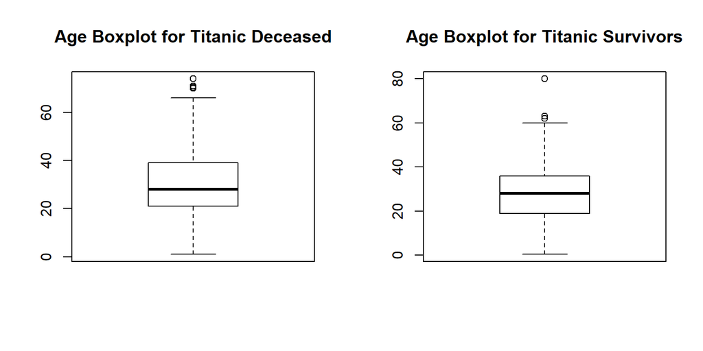

```r
par(mfrow=c(1,2))
titanic_data %>% drop_na() %>% filter(Survived==0) %>% select(Age) %>% boxplot(main='Age Boxplot for Titanic Deceased')
titanic_data %>% drop_na() %>% filter(Survived==1) %>% select(Age) %>% boxplot(main='Age Boxplot for Titanic Survivors')
```